# Lab 5: Dummies, Interactions and Demand for Fish

## Introduction

In economics, there is a strong history trying to understand market behavior. Properly identifying a market demand function is hard, but various authors have studied fish markets as examples of markets where a relatively homogeneous good (fish) with a short lifespan (its quality deteriorates if not bought promptly) is sold in competitive regional markets, such as the fish markets at Saumaty in Marseille, France or MERITAN in Ancona, Italy. Alan Kirman has been involved in a lot of this work in the past few decades trying to understand the complex interactions that produce market demand functions from not particularly consisten individual demand functions. Härdle and Kirman (1995) was one of his first papers to study the Marseille fish market, which he returned to for his book (Kirman 2010). He has also done a variety of work with co-authors on fish markets, such as that on the Ancona fish market (Gallegati et al. 2011). Prof Kirman has kindly provided me with the data from his Marseille studies and so we have the opportunity to look at this rather marvellous data set.

- Go here on Moodle to download the data: moodle.smith.edu/mod/resource/view.php?id=233898
- The codebook to understand what the data means is available on Moodle here: moodle.smith.edu/mod/resource/view.php?id=233897

```r
library(tidyverse)
```

Import the data as follows. Notice that this is *different* to how we’ve historically imported data. This is because the data are in a .txt file and so we can’t use `read.csv()`. Instead, we use `read_table()` from the `readr` package in the `tidyverse`.

```r
MarseilleBase <- read_table("../more/MARS.txt", col_names = FALSE)
```

Look at the .txt file. Why do you think we had to specify the option `col_names = FALSE`?

`head()` the data to look at it. It has an issue in one column (find the issue)

```r
head(MarseilleBase)
```

```
## # A tibble: 6 x 8
##      X1    X2                 X3     X4    X5    X6    X7    X8
##   <chr> <int>              <chr>  <int> <chr> <chr> <int> <int>
## 1   002 18064 ESCALE BASTIA 1002 880105 05415   077   110  4000
## 2   002 18070 ESCALE BASTIA 1002 880105 05415   044   120  2200
## 3   002 18078 PSS DE L'OPERA1002 880104 05505   214    90  6500
## 4   002 18081 GENTY PERTUIS 1002 880105 10080   214   150  6500
## 5   002 18085 MONTLAUR      1002 880102 10090   077   205  3600
## 6   002 18088 MONTLAUR      1002 880102 10090   044    60  1800
```

As you can see, we need to solve this problem. We can do this using the `separate()` function in `dplyr`, which is part of the `tidyverse`.

```r
Marseille <-
  MarseilleBase %>%
  separate(X3, c("X3a", "X3b"), sep = 14)
head(Marseille)
```

```
## # A tibble: 6 x 9
##      X1    X2            X3a   X3b     X4    X5    X6    X7    X8
##   <chr> <int>          <chr> <chr>  <int> <chr> <chr> <int> <int>
## 1   002 18064 ESCALE BASTIA   1002 880105 05415   077   110  4000
## 2   002 18070 ESCALE BASTIA   1002 880105 05415   044   120  2200
## 3   002 18078 PSS DE L'OPERA  1002 880104 05505   214    90  6500
## 4   002 18081 GENTY PERTUIS   1002 880105 10080   214   150  6500
## 5   002 18085 MONTLAUR        1002 880102 10090   077   205  3600
## 6   002 18088 MONTLAUR        1002 880102 10090   044    60  1800
```

What did I do above?

- Create a new data frame called `Marseille`
- Using the data frame `MarseilleBase`
- I use `separate` on the variable `X3`
- I ask `separate` to create two new variables: `X3a` and `X3b`
- Because the txt file has the names of the buyers limited to 14 characters, I ask `separate` to separate the variables at the 14th character
- I can now work with this data frame and rename my variables sensibly.

```r
Marseille <-
  Marseille %>%
  rename(sellerb = X1,
         lot = X2,
         nbuyer = X3a,
         seller = X3b,
         date = X4,
         buyerc = X5,
         fish = X6,
         tempa = X7,
         tempb = X8)
Mars <-
  Marseille %>%
  mutate(weight = tempa/10,
         price = tempb/100,
         fish = parse_number(fish))
head(Mars)
```

```
## # A tibble: 6 x 11
##   sellerb   lot         nbuyer seller   date buyerc  fish tempa tempb
##     <chr> <int>          <chr>  <chr>  <int>  <chr> <dbl> <int> <int>
## 1     002 18064 ESCALE BASTIA    1002 880105  05415    77   110  4000
## 2     002 18070 ESCALE BASTIA    1002 880105  05415    44   120  2200
## 3     002 18078 PSS DE L'OPERA   1002 880104  05505   214    90  6500
## 4     002 18081 GENTY PERTUIS    1002 880105  10080   214   150  6500
## 5     002 18085 MONTLAUR         1002 880102  10090    77   205  3600
## 6     002 18088 MONTLAUR         1002 880102  10090    44    60  1800
## # ... with 2 more variables: weight <dbl>, price <dbl>
```

- DO NOT run the code below yourselves.
- The sample size is huge and we don’t want to overload the server.
- Just look at the plot. What does it suggest?
- What does the line correspond to?
- What kind of pattern are you able to see?

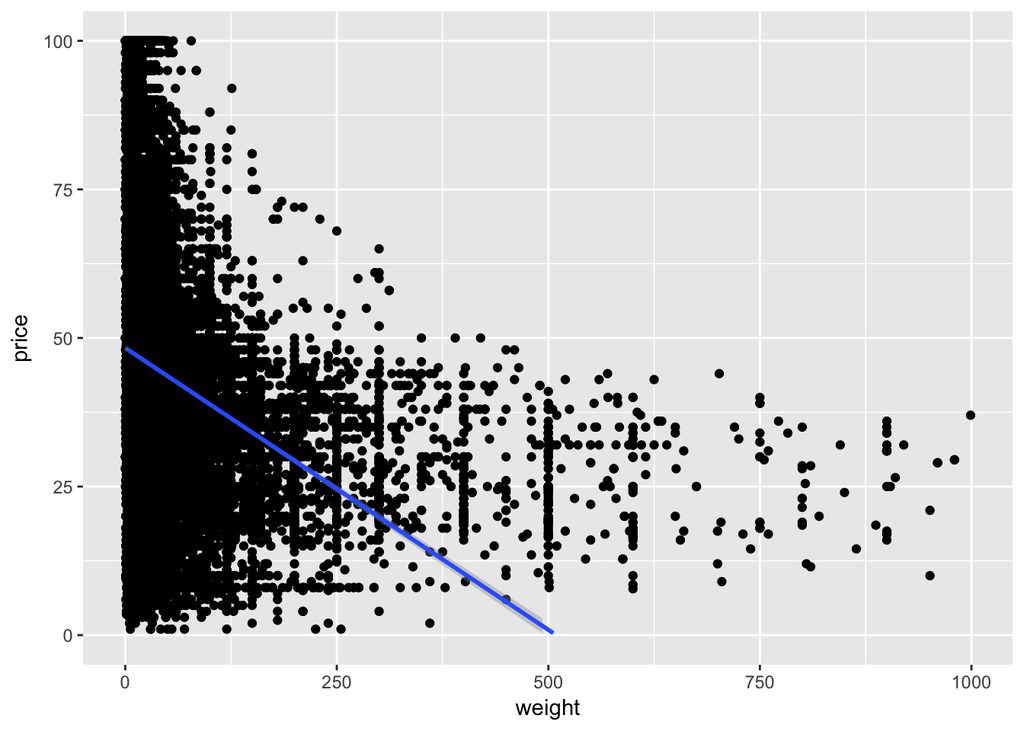

```r
Mars %>%
  ggplot(aes(x = weight, y = price)) +
  geom_point() +
  stat_smooth(method = "lm", formula = y ~ x,  size = 1) +
  ylim(0, 100)
```

Note, we don’t need a *linear* downward-sloping function…

- (Again DO NOT RUN THIS CODE)

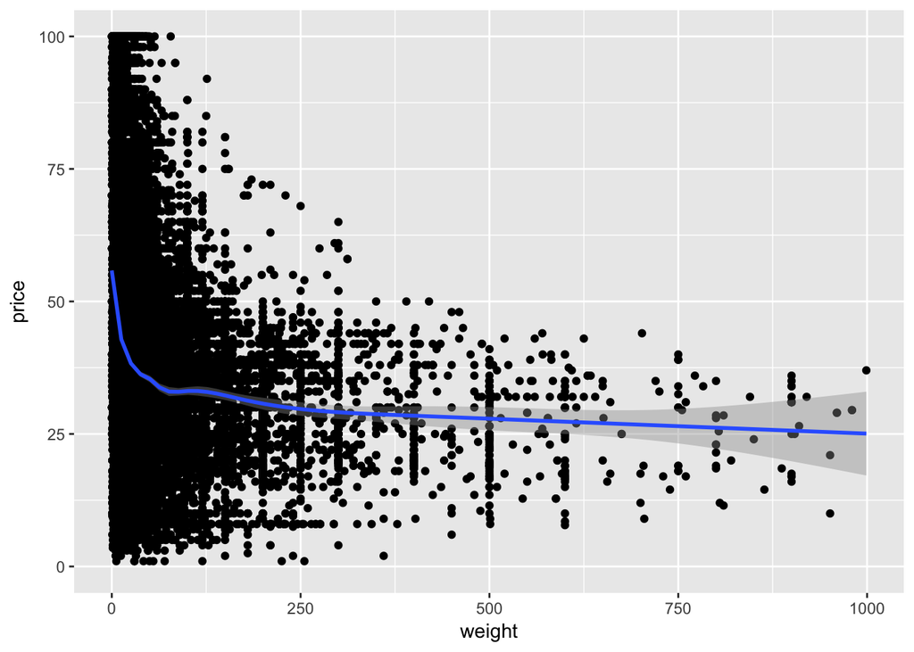

```r
Mars %>%
  ggplot(aes(x = weight, y = price)) +
  geom_point() +
  stat_smooth(method = "auto", size = 1) +
  ylim(0, 100)
```

## A basic linear regression

Notice that you can run a linear regression with the whole sample of fish:

```r
m1 <- lm(price ~ weight, data = Mars)
summary(m1)
```

```
##
## Call:
## lm(formula = price ~ weight, data = Mars)
##
## Residuals:
##    Min     1Q Median     3Q    Max
## -52.63 -20.45  -8.68  15.94 616.91
##
## Coefficients:
##              Estimate Std. Error t value Pr(>|t|)
## (Intercept) 54.365659   0.065227  833.49   <2e-16 ***
## weight      -0.123012   0.001865  -65.97   <2e-16 ***
## ---
## Signif. codes:  0 '***' 0.001 '**' 0.01 '*' 0.05 '.' 0.1 ' ' 1
##
## Residual standard error: 29.56 on 237159 degrees of freedom
##   (1 observation deleted due to missingness)
## Multiple R-squared:  0.01802,    Adjusted R-squared:  0.01802
## F-statistic:  4353 on 1 and 237159 DF,  p-value: < 2.2e-16
```

- What is the sign on the coefficient for weight?
- What is weight’s significance?
- What does the relationship mean in terms of economic theory?

## Filtering the Fish

Consult the Marseille Data Description document to check what the different kinds of fish are.

I have generated the following graph for one of the kinds of fish (Merlan) by filtering and then graphing the data.

Filtering for Merlan:

```r
MarsFish44 <-
  Mars %>%
  filter(fish == 44)
```

Graphing the Merlan data:

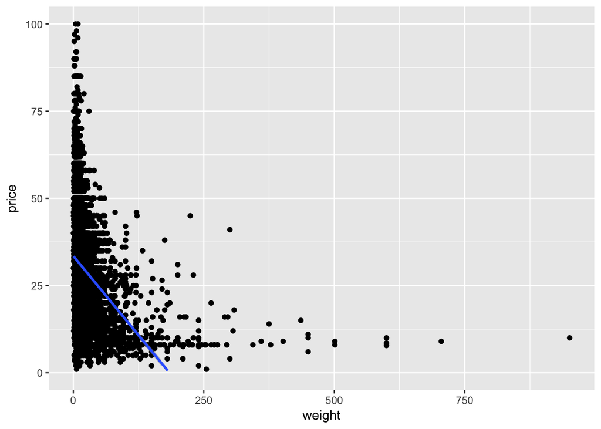

```r
MarsFish44 %>%
  ggplot(aes(x = weight, y = price)) +
  geom_point() +
  stat_smooth(method = "lm", formula = y ~ x, size = 1) +
  ylim(0, 100)
```

We can also run a linear regression just with the filtered Merlan data.

```r
OLSMerlan <- lm(price ~ weight, data = MarsFish44)
summary(OLSMerlan)
```

```
##
## Call:
## lm(formula = price ~ weight, data = MarsFish44)
##
## Residuals:
##    Min     1Q Median     3Q    Max
## -31.37  -8.03   0.45   7.45 345.26
##
## Coefficients:
##              Estimate Std. Error t value Pr(>|t|)
## (Intercept) 33.461832   0.060521  552.90   <2e-16 ***
## weight      -0.181625   0.003097  -58.64   <2e-16 ***
## ---
## Signif. codes:  0 '***' 0.001 '**' 0.01 '*' 0.05 '.' 0.1 ' ' 1
##
## Residual standard error: 12.08 on 53679 degrees of freedom
## Multiple R-squared:  0.06021,    Adjusted R-squared:  0.06019
## F-statistic:  3439 on 1 and 53679 DF,  p-value: < 2.2e-16
```

Do the following:

- Choose a fish in which you are interested and construct a data frame that contains only that kind of fish.
- Construct a plot for that fish’s quantity-price observations
- Run a linear regression model of that fish’s price-quantity relationship
- Summarize the regression output.
- Submit your html of this later.

# Multiple regression with dummy variables

We want to include dummy variables for the different kinds of fish in our regressions. So we need to check whether the fish variable is numeric or a factor. We could `head()` the data and see, but we can also get a “TRUE” or “FALSE” report using the `is.numeric()` or `is.factor()` functions.

```r
is.numeric(Mars$fish) #This must be true because I made it numeric
```

```
## [1] TRUE
```

```r
is.factor(Mars$fish) #This must be false unless you change it
```

```
## [1] FALSE
```

As you can see, we need to change `fish` into a *factor* variable because we want to use the factors as dummy variables.

- How would you do this?
- Do the variables have the labels you’d like them to have? (i.e. the names of the fish)
- Is there a way to remedy this?

### Some ideas for factors

We need to take the information from the Marseille Data Details document and create two sets of columns using the following idea: `ObjectName <- c(content1, content2, ..., contentn)`.

I would recommend you call the one object (with the numbers) `FishLevels` because it corresponds to the *levels* of your factor variable.

I would recommend you call the second object `FishLabels` because it corresponds to the *labels* of the fish that you want.

You will then use the function `factor()` inside the function `mutate()` (which you already know).

You would then do something like the following (note this won’t work because I don’t have actual values attributed to these objects yet).

```r
MarsFactorFish <-
  Mars %>%
  mutate(fishvariablename = factor(fishvariablename,
                                   levels = FishLevels,
                                   labels = FishLabels))
```

You should get something like the following when you head your data:

```r
FishLabels <- c("Merlan", "Carrelet", "Cabillaud", "Loup/Bar", " Raie Ange", "Raie (Entiere)", "Sole", "Turbot", "Cabillaud (Tranches)", "Sole (Filet)", "Annarrhyque (Filets)", "Loup (Filets)")
FishLevels <- c(44, 62, 77, 122, 204, 205, 214, 244, 285, 289, 314, 315)
Mars <-
  Mars %>%
  mutate(fish = factor(fish,
                       levels = FishLevels,
                       labels = FishLabels))
head(Mars)
```

```
## # A tibble: 6 x 11
##   sellerb   lot         nbuyer seller   date buyerc      fish tempa tempb
##     <chr> <int>          <chr>  <chr>  <int>  <chr>    <fctr> <int> <int>
## 1     002 18064 ESCALE BASTIA    1002 880105  05415 Cabillaud   110  4000
## 2     002 18070 ESCALE BASTIA    1002 880105  05415    Merlan   120  2200
## 3     002 18078 PSS DE L'OPERA   1002 880104  05505      Sole    90  6500
## 4     002 18081 GENTY PERTUIS    1002 880105  10080      Sole   150  6500
## 5     002 18085 MONTLAUR         1002 880102  10090 Cabillaud   205  3600
## 6     002 18088 MONTLAUR         1002 880102  10090    Merlan    60  1800
## # ... with 2 more variables: weight <dbl>, price <dbl>
```

## Fish Factors in the Multiple Regression

Now, include the fish variables as factors in our regression

```r
m2 <- lm(price ~ weight + fish, data = Mars)
summary(m2)
```

```
##
## Call:
## lm(formula = price ~ weight + fish, data = Mars)
##
## Residuals:
##     Min      1Q  Median      3Q     Max
## -108.07   -7.61   -0.01    8.19  559.08
##
## Coefficients:
##                            Estimate Std. Error t value Pr(>|t|)
## (Intercept)               32.373332   0.070891 456.665  < 2e-16 ***
## weight                    -0.071872   0.001057 -67.992  < 2e-16 ***
## fishCarrelet             -15.228267   0.416955 -36.523  < 2e-16 ***
## fishCabillaud             -0.762175   0.111204  -6.854 7.21e-12 ***
## fishLoup/Bar              79.294592   0.126323 627.712  < 2e-16 ***
## fish Raie Ange             4.903407   0.128050  38.293  < 2e-16 ***
## fishRaie (Entiere)        19.105380   3.316580   5.761 8.39e-09 ***
## fishSole                  33.302315   0.090079 369.702  < 2e-16 ***
## fishTurbot                40.010028   0.247857 161.424  < 2e-16 ***
## fishCabillaud (Tranches)   9.517823   0.630584  15.094  < 2e-16 ***
## fishSole (Filet)          46.448343   0.683419  67.965  < 2e-16 ***
## fishAnnarrhyque (Filets)  12.531891   0.299675  41.818  < 2e-16 ***
## fishLoup (Filets)         13.706294   0.208501  65.737  < 2e-16 ***
## ---
## Signif. codes:  0 '***' 0.001 '**' 0.01 '*' 0.05 '.' 0.1 ' ' 1
##
## Residual standard error: 16.24 on 237042 degrees of freedom
##   (107 observations deleted due to missingness)
## Multiple R-squared:  0.7036, Adjusted R-squared:  0.7036
## F-statistic: 4.689e+04 on 12 and 237042 DF,  p-value: < 2.2e-16
```

- What do the different coefficients on the categorical (dummy) variables mean?
- Can you provide new output for the fish regressions using stargazer?

```r
m3 <- lm(price ~ weight + fish + weight*fish, data = Mars)
summary(m3)
```

```
##
## Call:
## lm(formula = price ~ weight + fish + weight * fish, data = Mars)
##
## Residuals:
##     Min      1Q  Median      3Q     Max
## -108.88   -7.86   -0.03    8.04  559.41
##
## Coefficients:
##                                   Estimate Std. Error t value Pr(>|t|)
## (Intercept)                      33.461832   0.080694 414.676  < 2e-16 ***
## weight                           -0.181625   0.004130 -43.982  < 2e-16 ***
## fishCarrelet                    -16.045520   0.509098 -31.518  < 2e-16 ***
## fishCabillaud                    -2.939527   0.122115 -24.072  < 2e-16 ***
## fishLoup/Bar                     79.198454   0.148148 534.591  < 2e-16 ***
## fish Raie Ange                    4.262459   0.149862  28.443  < 2e-16 ***
## fishRaie (Entiere)               35.941919   5.033931   7.140 9.36e-13 ***
## fishSole                         33.210235   0.101279 327.908  < 2e-16 ***
## fishTurbot                       40.505680   0.298213 135.828  < 2e-16 ***
## fishCabillaud (Tranches)          8.618767   0.969096   8.894  < 2e-16 ***
## fishSole (Filet)                 46.469263   0.737629  62.998  < 2e-16 ***
## fishAnnarrhyque (Filets)          9.922578   0.332157  29.873  < 2e-16 ***
## fishLoup (Filets)                11.438594   0.224946  50.850  < 2e-16 ***
## weight:fishCarrelet               0.085692   0.026419   3.244  0.00118 **
## weight:fishCabillaud              0.156957   0.004408  35.610  < 2e-16 ***
## weight:fishLoup/Bar              -0.017133   0.009590  -1.787  0.07400 .
## weight:fish Raie Ange             0.037671   0.011757   3.204  0.00135 **
## weight:fishRaie (Entiere)        -4.018855   0.877712  -4.579 4.68e-06 ***
## weight:fishSole                   0.019803   0.004686   4.226 2.38e-05 ***
## weight:fishTurbot                -0.033145   0.015344  -2.160  0.03076 *
## weight:fishCabillaud (Tranches)   0.098372   0.044602   2.206  0.02742 *
## weight:fishSole (Filet)          -0.086347   0.051126  -1.689  0.09124 .
## weight:fishAnnarrhyque (Filets)   0.149352   0.005607  26.634  < 2e-16 ***
## weight:fishLoup (Filets)          0.150366   0.004985  30.164  < 2e-16 ***
## ---
## Signif. codes:  0 '***' 0.001 '**' 0.01 '*' 0.05 '.' 0.1 ' ' 1
##
## Residual standard error: 16.11 on 237031 degrees of freedom
##   (107 observations deleted due to missingness)
## Multiple R-squared:  0.7085, Adjusted R-squared:  0.7085
## F-statistic: 2.505e+04 on 23 and 237031 DF,  p-value: < 2.2e-16
```

- What does the model say? (that is, interpret the *equation* of the regressionl line)
- What is an *interaction term*?
- What do the coefficients on each of the variables mean now?

## References

Gallegati, Mauro, Gianfranco Giulioni, Alan Kirman, and Antonio Palestrini. 2011. “What’s That Got to Do with the Price of Fish? Buyers Behavior on the Ancona Fish Market.” *Journal of Economic Behavior & Organization* 80 (1): 20–33. doi:https://doi.org/10.1016/j.jebo.2011.01.011.

Härdle, Wolfgang, and Alan Kirman. 1995. “Nonclassical Demand: A Model-Free Examination of Price-Quantity Relations in the Marseille Fish Market.” *Journal of Econometrics* 67 (1): 227–57. doi:https://doi.org/10.1016/0304-4076(94)01634-C.

Kirman, Alan. 2010. *Complex Economics: Individual and Collective Rationality*. Routledge.